# sd4

The October 30, 2020, Mw 7.0 Samos-Izmir earthquake was the largest seismic event in the Aegean Sea in recent years. The event caused building collapses and about 100 fatalities at Izmir, while a moderate tsunami following the earthquake hit the nearby island of Samos to the South and the coast of Türkiye to the North, causing one fatality.

This event has been used as a test case for an end-to-end execution of the PTF workflow in its basic capabilities, including on-the-fly tsunami simulations.

The original PTF code is available from the DT-GEO workflow registry (https://gitlab.com/dtgeo/workflow-management-system/workflow-registry/-/tree/main/DTC61/WF6101?ref_type=heads). For the sake of simplicity and conciseness, the codes in this notebook (as well in the external functions.ipynb notebook) have been revised and some general options have been removed, to focus on the specific site demonstrator.

Moreover, Step 4 is not provided here since the conversion of the hazard into Alert Levels is a prerogative of the TSP (Tsunami Service Providers).

To execute the notebook a Python environment including all the required modules must be activated. Anyway, an already executed html version of the notebook is also provided.

```python
import os
import sys
import numpy as np
import h5py
import scipy
from scipy.stats import norm
```

```python
#local inputs
input_folder = 'input'
# input data folder
data_folder = os.path.join(input_folder,'INPUT4PTF')
#output folder
output_folder = 'output'

# load external functions from a Jupyter notebook
%run ./functions.ipynb
```

```python
# input parameters
workdir = './'
sigma = 2.0
sigma_inn = sigma
sigma_out = sigma + 0.5
negligible_prob = 2*norm.cdf(-1. * sigma)
```

```python
# load the event file and build the event dictionary
event_file = os.path.join(input_folder, '2020_1030_samos.json')
s = open(event_file, 'r').read()
jsn_object = eval(s)

event_dict = int_quake_cat2dict(json_object=jsn_object)

event_dict['event_file'] = event_file
event_dict['sigma'] = sigma

event_dict = compute_position_sigma_lat_lon(event_dict)
print(event_dict)
```

```
{'eventid': '99999999', 'originid': '99999999', 'lat': 37.839, 'lon': 26.829, 'depth': 9.8, 'ot': '2020-10-30T00:00', 'mag': 6.978, 'mag_percentiles': {'p16': 6.827, 'p50': 6.978, 'p84': 7.153}, 'MagSigma': 0.1629999999999998, 'type': 'earthquake', 'mag_type': 'Mwp', 'ee_utm': (np.float64(484953.887…
       [ 4.8435, 18.1122]]), 'PosMean_2d': array([ 484953.8879506 , 4187965.75397893]), 'PosCovMat_3d': array([[13.9478,  4.8435,  0.2781],
       [ 4.8435, 18.1122,  0.1786],
       [ 0.2781,  0.1786, 10.2529]]), 'PosCovMat_3dm': array([[13947800.,  4843500.,   278100.],
       [ 4843500., 18112200.,   178600.],
       [  278100.,   178600., 10252900.]]), 'PosMean_3d': array([ 484953.8879506 , 4187965.75397893,    9800.        ]), 'event_file': 'input/2020_1030_samos.json', 'sigma': 2.0, 'position_BS_sigma_yy': 41266.77357715076, 'position_BS_sigma_xx': 40745.60588896234, 'position_BS_sigma_xy': 39211.72584…
```

```
Total number of POIs: 3889
```

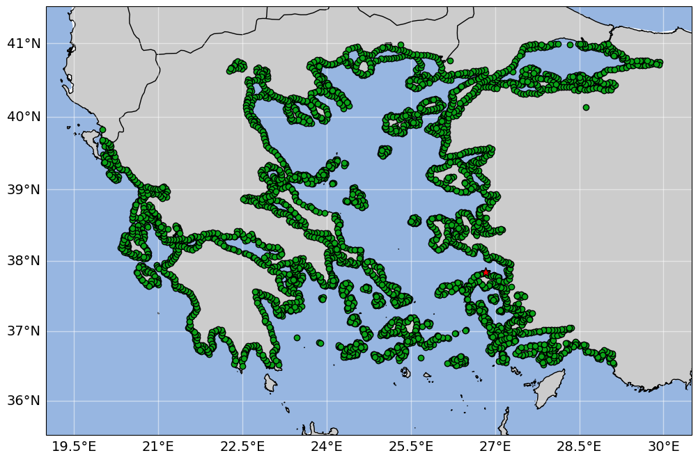

```python
pois = np.load(os.path.join(input_folder, 'POIs_local_domain_2020_1030_samos.npy'), allow_pickle=True).item()
n_pois = len(pois['pois_coords'])
print(f'Total number of POIs: {n_pois}')

pois_coords = pois['pois_coords']
pois_index = np.arange(n_pois)
plot_pois(pois_coords, pois_index, event_dict)
```

```python
# loading input data

thresholds, intensity_measure = load_intensity_thresholds(data_folder)

LongTermInfo = dict()

LongTermInfo['Regionalization'] = np.load(os.path.join(data_folder, 'regionalization.npy'), allow_pickle=True).item()
LongTermInfo['Discretizations'] = np.load(os.path.join(data_folder, 'discretizations.npy'), allow_pickle=True).item()

LongTermInfo['Model_Weights'] =  load_Model_Weights(data_folder)
Region_files = load_region_files( LongTermInfo['Regionalization']['Npoly'], LongTermInfo['Regionalization']['Ttypes'], data_folder)

Mesh = np.load(os.path.join(data_folder, 'mesh_files/slab_meshes_mediterranean.npy'), allow_pickle=True).item()
PSBarInfo = np.load(os.path.join(data_folder, 'PSBarInfo.npy'), allow_pickle=True).item()
```

**STEP1 - define the ensemble of scenarios**

```python
ellipses = build_ellipsoid_objects(event_dict, sigma_inn, sigma_out)
LongTermInfo, PSBarInfo = conversion_to_utm(LongTermInfo, event_dict, PSBarInfo)

#separation BS/PS
lambda_bsps = load_lambda_BSPS(sigma, event_dict, data_folder)
lambda_bsps = separation_lambda_BSPS(event_dict, lambda_bsps, LongTermInfo, Mesh)

#pre-selection of scenarios
pre_selection = pre_selection_of_scenarios(sigma, event_dict, LongTermInfo, PSBarInfo, ellipses)
```

```
 --> Volume of the Gaussian Ellipsoid: 4.61443718e+12 [m^3]
 --> N. Tetra in the Gaussian Ellipsoid: 402
 --> Volume of Tetra in the Gaussian Ellipsoid: 4.21111798e+12 [m^3]
 --> Volume difference Gaussian <--> Tetra: 8.74 [%]
 --> Distance between tetra and slabs:
     --> Min distance from slab HeA    184.141 [km]
         --> Nr of PS tetra with dist.  < 10.0 [km] from slab HeA : 0  (effective: 0)
         --> Nr of BS tetra with dist. >= 10.0 [km] from slab HeA : 402  (effective: 402)
     --> Min distance from slab CaA    612.902 [km]
         --> Nr of PS tetra with dist.  < 10.0 [km] from slab CaA : 0  (effective: 0)
         --> Nr of BS tetra with dist. >= 10.0 [km] from slab CaA : 402  (effective: 402)
     --> Min distance from slab CyA    349.453 [km]
         --> Nr of PS tetra with dist.  < 10.0 [km] from slab CyA : 0  (effective: 0)
         --> Nr of BS tetra with dist. >= 10.0 [km] from slab CyA : 402  (effective: 402)
 --> lambda PS: 0.0000e+00  Volume PS: 0.0000e+00 [m^3]
 --> lambda BS: 1.0000e+00  Volume BS: 4.2111e+12 [m^3]
 -->                     Volume BS-PS: 4.2111e+12 [m^3]
 --> BS magnitude values: [6.8012 7.0737]
 --> PS magnitude values: [6.8012 7.0737]
 --> BS2_Position inner:   36 positions found
 --> BS2_Position outer:   53 positions found
 --> PS2_Position inner:    0 positions found
 --> PS2_Position outer:    0 positions found
Warning: PS are excluded since no scenarios are found in the inner positions (within sigma_inn)
```

```python
print('BS scenarios: {}'.format(pre_selection['BS_scenarios']))
print('PS scenarios: {}'.format(pre_selection['PS_scenarios']))
```

```
BS scenarios: True
PS scenarios: False
```

```python
short_term_probability  = short_term_probability_distribution(event_dict, negligible_prob, LongTermInfo, PSBarInfo, lambda_bsps, pre_selection)
probability_scenarios = compute_probability_scenarios(LongTermInfo, pre_selection, short_term_probability, Region_files)
```

```
 --> Compute magnitude cumulative distribution
 --> Negligible Probability: 0.0455
 --> Probability BS = 8.8816e-01 --> compute BS = True
 --> Probability PS = 0.0000e+00 --> compute PS = False
 --> Set grid Integration
 --> Used regions for BS : [30. 31. 32.]
 --> Total BS scenarios probability pre-renormalization: 0.88816
 --> Total PS scenarios probability pre-renormalization: 0.00000
     --> Total BS and PS probabilty renormalized to 1
 --> Total_BS_Scenarios:   38736
 --> Total_PS_Scenarios:       0
```

```python
# saving scenario lists (parameters and probabilities)
file_bs_list = os.path.join(output_folder, 'step1_BS_scenarios_list.txt')
file_bs_prob = os.path.join(output_folder, 'step1_BS_scenarios_prob.npy')

par_scenarios_bs = probability_scenarios['par_scenarios_bs']
len_scenarios_bs, len_pars = par_scenarios_bs.shape

fmt = "{:f}".format
with open(file_bs_list, 'w') as f_list_bs:
    for ic in range(len_scenarios_bs):
        pars = " ".join(fmt(par_scenarios_bs[ic, item]) for item in range(1, len_pars))
        ireg = "{:.0f}".format(par_scenarios_bs[ic, 0])
        f_list_bs.write("{:s} {:s} {:s}\n".format(str(ic+1), ireg, pars))

prob_scenarios_bs = probability_scenarios['ProbScenBS']
np.save(file_bs_prob, prob_scenarios_bs)

print('BS scenarios saved in: {}'.format(file_bs_list))
print('BS probabilities saved in: {}'.format(file_bs_prob))
```

```
BS scenarios saved in: output/step1_BS_scenarios_list.txt
BS probabilities saved in: output/step1_BS_scenarios_prob.npy
```

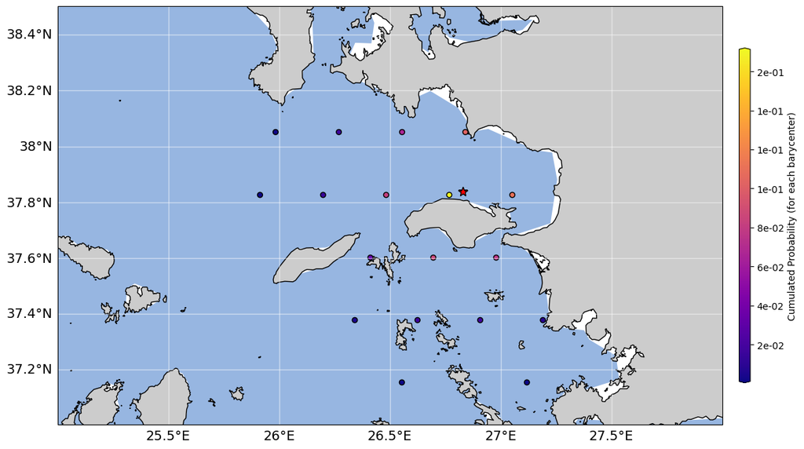

```python
# plot scenarios
plot_barycenters(par_scenarios_bs[:,2:4], prob_scenarios_bs, event_dict)
```

**STEP 2 - Scenario modeling**

Step 2 is not going to be executed in this notebook, since the tsunami simulations are already done and stored in the SDL (https://sdl.hpc.cineca.it). The final output of this step (nc file including the maximum wave height from each scenario at each POI) is assumed to be produced in the output folder and will be loaded for the further steps

```python
file_hmax_sim_bs = os.path.join(output_folder, 'step2_hmax_sim_BS.nc')
imax_scenarios_bs = h5py.File(file_hmax_sim_bs, 'r')
mih_bs = np.array(imax_scenarios_bs['ts_p2t_gl'])
```

**STEP3 - Hazard aggregation**

```python
print('Computing hazard curves from BS scenarios')
# The execution of this cell requires a few minutes (<10 min).
# A different optimized strategy is implemented in the original PTF code, but it is not applicable here due to memory issues.
hc_pois_bs = compute_hazard_curves(mih_bs, prob_scenarios_bs, n_pois, thresholds, sigma)
```

```
Computing hazard curves from BS scenarios
```

```python
hc_pois = hc_pois_bs

list_percentiles = [50, 15, 10, 5, 1]
percentiles = np.array(list_percentiles) * 0.01
n_percentiles = len(percentiles)
mih_percentiles = np.zeros((n_pois, n_percentiles))

for i in range(n_pois):
    mih_percentiles[i,:] = np.interp(percentiles, hc_pois[i,::-1], thresholds[::-1])

hc_d = dict()
hc_d['mean'] = scipy.integrate.simpson(hc_pois, thresholds)

# percentiles' labels are expressed as 1-p since they represent the survival function (not exceedance)
for ip, percentile in enumerate(percentiles):
    if percentile == 0:
        print('Percentile 100 is not allowed.')
    elif percentile != 0.0001:
        hc_d['p' +  '{:.0f}'.format((1-percentile)*100).zfill(2)] = mih_percentiles[:,ip]
    else:
        hc_d['envelope'] = mih_percentiles[:,ip]
```

```python
#saving hazard curves and percentiles
file_hc_pois = os.path.join(output_folder, 'step3_hazard_curves.npz')
file_percentiles = os.path.join(output_folder, 'step3_hazard_curves_percentiles.npy')

hazard_curves_pois_sparse = scipy.sparse.csr_matrix(hc_pois.astype(np.float32))
scipy.sparse.save_npz(file_hc_pois, hazard_curves_pois_sparse)
np.save(file_percentiles, hc_d, allow_pickle=True)
```

**STEP5 - Plotting**

```
Selected POIs:
 [[26.78333 37.815  ]
 [27.24554 37.79167]
 [26.84839 38.03333]
 [26.3     38.21795]
 [26.24167 37.65815]
 [26.30833 38.98363]
 [26.03109 38.175  ]]
```

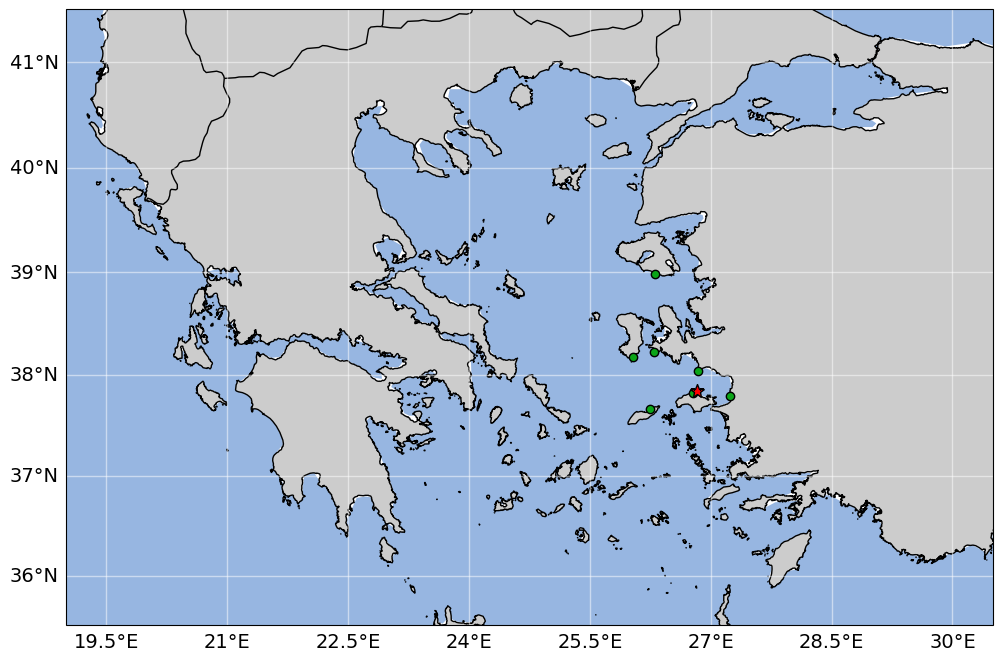

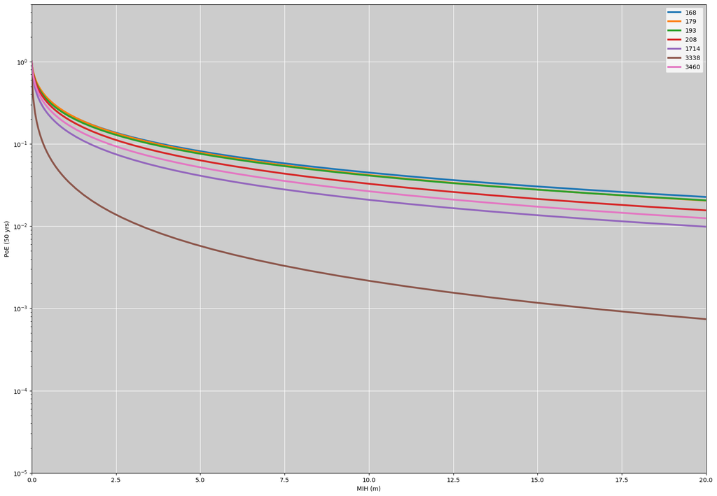

```python
# hazard curves on seleted pois
selected_pois_ind = [168, 179, 193, 208, 1714, 3338, 3460]
print('Selected POIs: \n {}'.format(pois_coords[selected_pois_ind]))
plot_pois(pois_coords, selected_pois_ind, event_dict)
plot_hazard_curve(selected_pois_ind, thresholds, hc_pois)
```

```
Plotting hazard maps
mapping ... mean
mapping ... p50
mapping ... p85
mapping ... p90
mapping ... p95
mapping ... p99
```

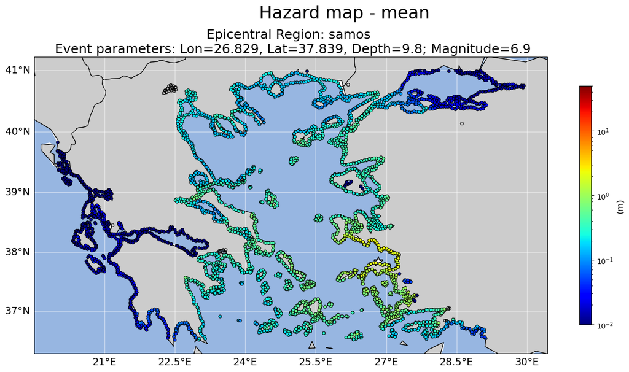

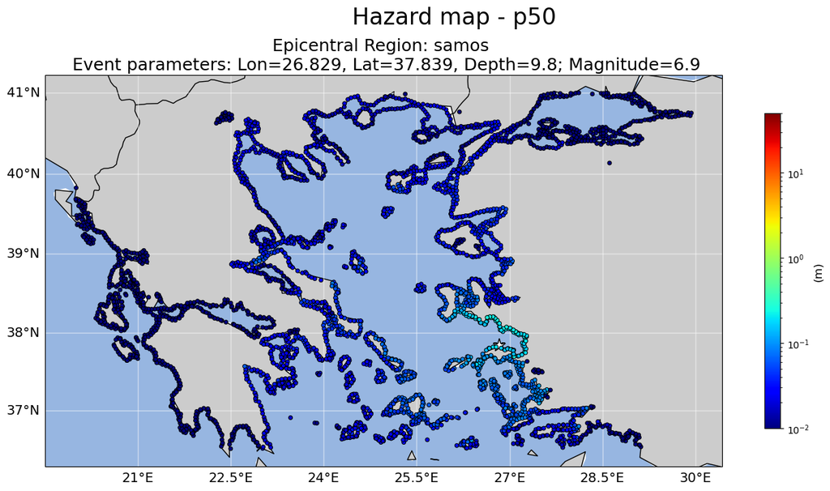

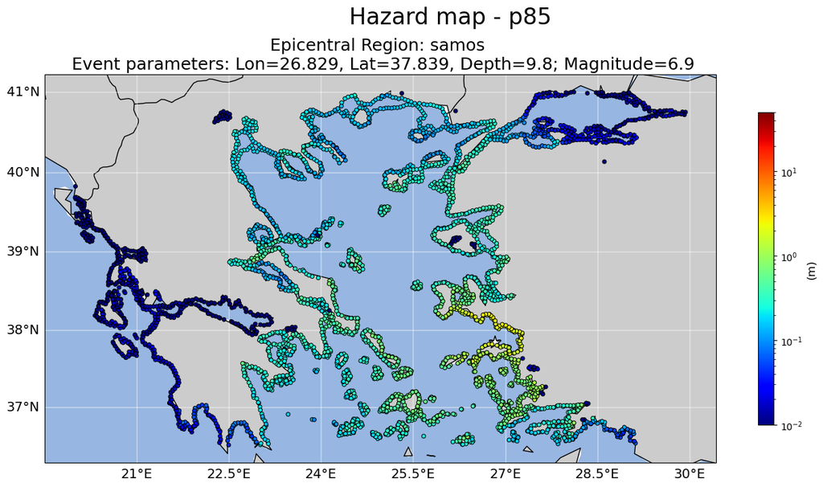

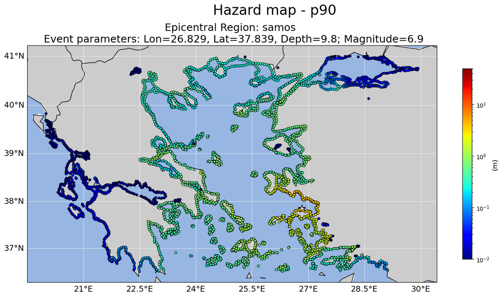

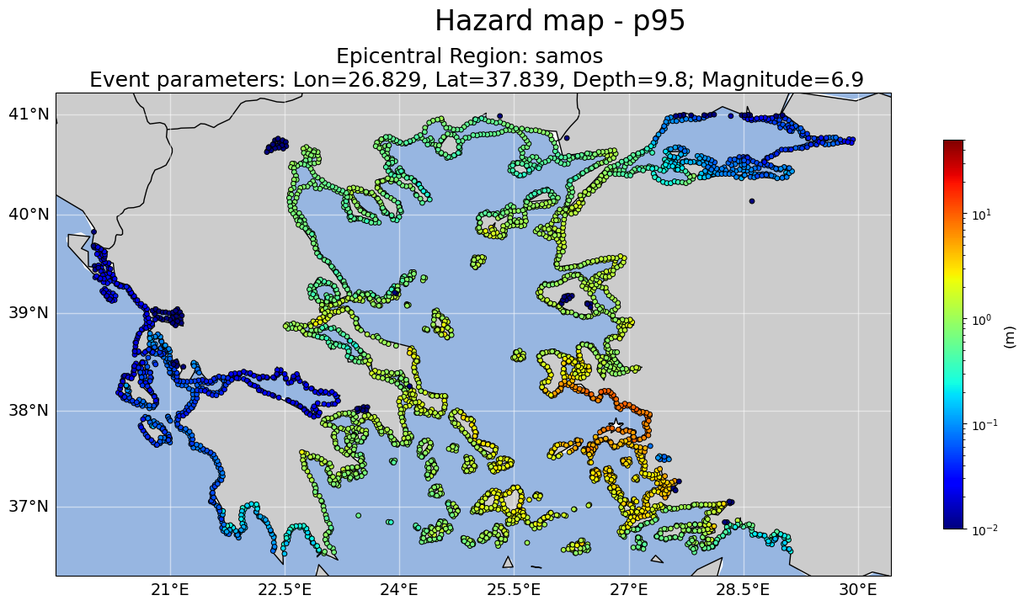

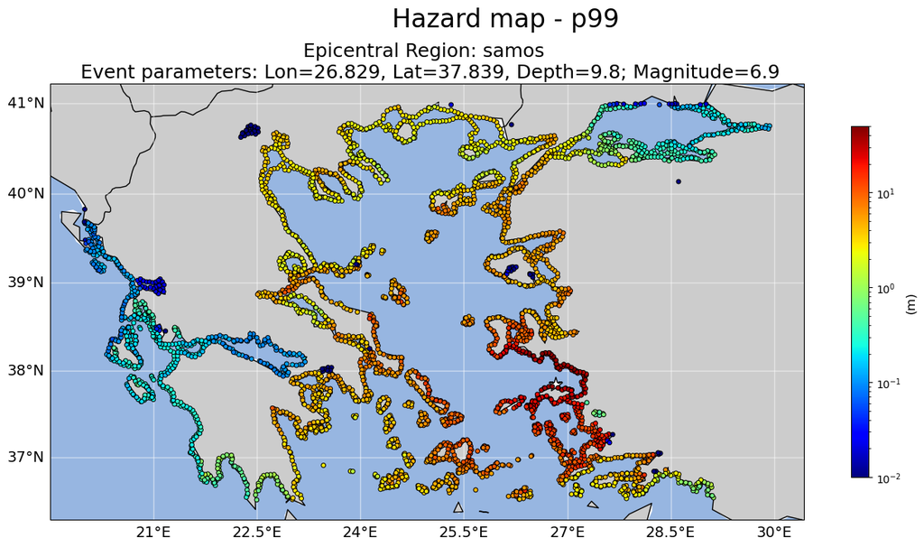

```python
# hazard maps
print('Plotting hazard maps')
plot_hazard_maps(pois_coords, hc_d, event_dict, "HazMap")
```